# No-show appointments_2

## Project: Investigate a Dataset - [No-show appointments]

- Introduction
- Data Wrangling
- Exploratory Data Analysis
- Conclusions

## Introduction

### Data Description

This data collects information from over 100k medical appointments in Brazil and is focused on the question of whether or not patients show up for their appointment. The following columns are shown on the dataset and they include 'PatientID' is a unique patient identifier 'AppointmentID' is a unique appointment identifier 'ScheduledDay' details what day the patient is set up to come in. 'Age' patients's age in years. 'Neighborhood' details the location of the hospital. 'Scholarship' deatails whether the patient is enrolled in a Brazilian government sponsored welfare program. 'Hypertension' details whether patient has hypertension or not. 'Diabetes' details whether patient has diabetes or not. 'Alcoholism' tells whether a patient suffers alcohol addiction. 'Handicap' gives information on whether a patient has physical disability or not. 'SMS_received' tells if a patient got an sms reminder or not 'show' tells whether the patient showed up for a scheduled appointment or not.

### Questions for Analysis

```
-How does gender affect a patients likelihood of showing up for scheduled appointments.

-Are males more likely to show up than females.

-Evaluate relationship between age and attendance

-How does age and gender affect attendance

-Does scholarship(govt sponsored welfare) affect attendance

-Does sms reminder improve attendance.
```

```python
#import packages for analysis
import pandas as pd
import numpy as np
import matplotlib.pyplot as plt
%matplotlib inline
import seaborn as sns
from scipy import stats
```

## Data Wrangling

```python
#Loading datasets
df = pd.read_csv(r'C:\Users\veikt\Documents\Victor Obi\2022\Data analysis project\Udacity\Lesson_1\Project\noshowappointments-kagglev2-may-2016.csv')
```

```python
#Inspecting dataset
df.head()
```

|  | PatientId | AppointmentID | Gender | ScheduledDay | AppointmentDay | Age | Neighbourhood | Scholarship | Hipertension | Diabetes | Alcoholism | Handcap | SMS_received | No-show |
| --- | --- | --- | --- | --- | --- | --- | --- | --- | --- | --- | --- | --- | --- | --- |
| 0 | 2.987250e+13 | 5642903 | F | 2016-04-29T18:38:08Z | 2016-04-29T00:00:00Z | 62 | JARDIM DA PENHA | 0 | 1 | 0 | 0 | 0 | 0 | No |
| 1 | 5.589978e+14 | 5642503 | M | 2016-04-29T16:08:27Z | 2016-04-29T00:00:00Z | 56 | JARDIM DA PENHA | 0 | 0 | 0 | 0 | 0 | 0 | No |
| 2 | 4.262962e+12 | 5642549 | F | 2016-04-29T16:19:04Z | 2016-04-29T00:00:00Z | 62 | MATA DA PRAIA | 0 | 0 | 0 | 0 | 0 | 0 | No |
| 3 | 8.679512e+11 | 5642828 | F | 2016-04-29T17:29:31Z | 2016-04-29T00:00:00Z | 8 | PONTAL DE CAMBURI | 0 | 0 | 0 | 0 | 0 | 0 | No |
| 4 | 8.841186e+12 | 5642494 | F | 2016-04-29T16:07:23Z | 2016-04-29T00:00:00Z | 56 | JARDIM DA PENHA | 0 | 1 | 1 | 0 | 0 | 0 | No |

```python
#checking total rows and columns
df.shape
```

```
(110527, 14)
```

```python
#checking summary statistics of numerical columns
df.describe()
```

|  | PatientId | AppointmentID | Age | Scholarship | Hipertension | Diabetes | Alcoholism | Handcap | SMS_received |
| --- | --- | --- | --- | --- | --- | --- | --- | --- | --- |
| count | 1.105270e+05 | 1.105270e+05 | 110527.000000 | 110527.000000 | 110527.000000 | 110527.000000 | 110527.000000 | 110527.000000 | 110527.000000 |
| mean | 1.474963e+14 | 5.675305e+06 | 37.088874 | 0.098266 | 0.197246 | 0.071865 | 0.030400 | 0.022248 | 0.321026 |
| std | 2.560949e+14 | 7.129575e+04 | 23.110205 | 0.297675 | 0.397921 | 0.258265 | 0.171686 | 0.161543 | 0.466873 |
| min | 3.921784e+04 | 5.030230e+06 | -1.000000 | 0.000000 | 0.000000 | 0.000000 | 0.000000 | 0.000000 | 0.000000 |
| 25% | 4.172614e+12 | 5.640286e+06 | 18.000000 | 0.000000 | 0.000000 | 0.000000 | 0.000000 | 0.000000 | 0.000000 |
| 50% | 3.173184e+13 | 5.680573e+06 | 37.000000 | 0.000000 | 0.000000 | 0.000000 | 0.000000 | 0.000000 | 0.000000 |
| 75% | 9.439172e+13 | 5.725524e+06 | 55.000000 | 0.000000 | 0.000000 | 0.000000 | 0.000000 | 0.000000 | 1.000000 |
| max | 9.999816e+14 | 5.790484e+06 | 115.000000 | 1.000000 | 1.000000 | 1.000000 | 1.000000 | 4.000000 | 1.000000 |

```python
# checking for null records and column datatype
df.info()
```

```
<class 'pandas.core.frame.DataFrame'>
RangeIndex: 110527 entries, 0 to 110526
Data columns (total 14 columns):
 #   Column          Non-Null Count   Dtype
---  ------          --------------   -----
 0   PatientId       110527 non-null  float64
 1   AppointmentID   110527 non-null  int64
 2   Gender          110527 non-null  object
 3   ScheduledDay    110527 non-null  object
 4   AppointmentDay  110527 non-null  object
 5   Age             110527 non-null  int64
 6   Neighbourhood   110527 non-null  object
 7   Scholarship     110527 non-null  int64
 8   Hipertension    110527 non-null  int64
 9   Diabetes        110527 non-null  int64
 10  Alcoholism      110527 non-null  int64
 11  Handcap         110527 non-null  int64
 12  SMS_received    110527 non-null  int64
 13  No-show         110527 non-null  object
dtypes: float64(1), int64(8), object(5)
memory usage: 11.8+ MB
```

```python
# Checking dataset for missing values
df.isnull().sum()
```

```
PatientId         0
AppointmentID     0
Gender            0
ScheduledDay      0
AppointmentDay    0
Age               0
Neighbourhood     0
Scholarship       0
Hipertension      0
Diabetes          0
Alcoholism        0
Handcap           0
SMS_received      0
No-show           0
dtype: int64
```

```python
# Inspecting dataset for duplicate records
df.duplicated().sum()
```

```
0
```

```python
# checking for unique records in each column
df.nunique()
```

```
PatientId          62299
AppointmentID     110527
Gender                 2
ScheduledDay      103549
AppointmentDay        27
Age                  104
Neighbourhood         81
Scholarship            2
Hipertension           2
Diabetes               2
Alcoholism             2
Handcap                5
SMS_received           2
No-show                2
dtype: int64
```

```python
#inspecting Age column
df["Age"].value_counts()
```

```
 0      3539
 1      2273
 52     1746
 49     1652
 53     1651
        ...
 115       5
 100       4
 102       2
 99        1
-1         1
Name: Age, Length: 104, dtype: int64
```

### Data cleaning

A breif inspection of that dataset shows 110527 rows and 14 columns, No null records.

Convert column labels to lower case. Renaming

Datatypes range from float64, int64 to objects. However, 2 columns(ScheduledDay, AppointmentDay) appears to have the wrong datatype. Both are recorded as objects as opposed to datetime datatype and will require datatype conversion.

Time lapse bewtween scheduledday and Appointmentday

Edit column labels to lower case.

Also creating a new column to show day of the week may be needed.

Age column contains one negative age and may need to be dropped.

Renaming no-show column to show. This was done to avoid confusion. Also converting the yes/no records to 0/1 int.

```python
# Changing column labels to lower case
df.columns = df.columns.str.lower()
```

```python
# Confirming changes made
df.head()
```

|  | patientid | appointmentid | gender | scheduledday | appointmentday | age | neighbourhood | scholarship | hipertension | diabetes | alcoholism | handcap | sms_received | no-show |
| --- | --- | --- | --- | --- | --- | --- | --- | --- | --- | --- | --- | --- | --- | --- |
| 0 | 2.987250e+13 | 5642903 | F | 2016-04-29T18:38:08Z | 2016-04-29T00:00:00Z | 62 | JARDIM DA PENHA | 0 | 1 | 0 | 0 | 0 | 0 | No |
| 1 | 5.589978e+14 | 5642503 | M | 2016-04-29T16:08:27Z | 2016-04-29T00:00:00Z | 56 | JARDIM DA PENHA | 0 | 0 | 0 | 0 | 0 | 0 | No |
| 2 | 4.262962e+12 | 5642549 | F | 2016-04-29T16:19:04Z | 2016-04-29T00:00:00Z | 62 | MATA DA PRAIA | 0 | 0 | 0 | 0 | 0 | 0 | No |
| 3 | 8.679512e+11 | 5642828 | F | 2016-04-29T17:29:31Z | 2016-04-29T00:00:00Z | 8 | PONTAL DE CAMBURI | 0 | 0 | 0 | 0 | 0 | 0 | No |
| 4 | 8.841186e+12 | 5642494 | F | 2016-04-29T16:07:23Z | 2016-04-29T00:00:00Z | 56 | JARDIM DA PENHA | 0 | 1 | 1 | 0 | 0 | 0 | No |

```python
# rename coulmn headers to reflect proper naming convention.

df = df.rename(columns={'patientid':'patient_id', 'appointmentid':'appointment_id', 'scheduledday':'scheduled_day', 'appointmentday':'appointment_day','hipertension': 'hypertension', 'handcap':'handicap'})
```

```python
# confirming changes made
df.head()
```

|  | patient_id | appointment_id | gender | scheduled_day | appointment_day | age | neighbourhood | scholarship | hypertension | diabetes | alcoholism | handicap | sms_received | no-show |
| --- | --- | --- | --- | --- | --- | --- | --- | --- | --- | --- | --- | --- | --- | --- |
| 0 | 2.987250e+13 | 5642903 | F | 2016-04-29T18:38:08Z | 2016-04-29T00:00:00Z | 62 | JARDIM DA PENHA | 0 | 1 | 0 | 0 | 0 | 0 | No |
| 1 | 5.589978e+14 | 5642503 | M | 2016-04-29T16:08:27Z | 2016-04-29T00:00:00Z | 56 | JARDIM DA PENHA | 0 | 0 | 0 | 0 | 0 | 0 | No |
| 2 | 4.262962e+12 | 5642549 | F | 2016-04-29T16:19:04Z | 2016-04-29T00:00:00Z | 62 | MATA DA PRAIA | 0 | 0 | 0 | 0 | 0 | 0 | No |
| 3 | 8.679512e+11 | 5642828 | F | 2016-04-29T17:29:31Z | 2016-04-29T00:00:00Z | 8 | PONTAL DE CAMBURI | 0 | 0 | 0 | 0 | 0 | 0 | No |
| 4 | 8.841186e+12 | 5642494 | F | 2016-04-29T16:07:23Z | 2016-04-29T00:00:00Z | 56 | JARDIM DA PENHA | 0 | 1 | 1 | 0 | 0 | 0 | No |

```python
#inspecting dataset for datatypes
df.dtypes
```

```
patient_id         float64
appointment_id       int64
gender              object
scheduled_day       object
appointment_day     object
age                  int64
neighbourhood       object
scholarship          int64
hypertension         int64
diabetes             int64
alcoholism           int64
handicap             int64
sms_received         int64
no-show             object
dtype: object
```

```python
#changing scheduled_day, appointment_day to datetime
for col in ["scheduled_day", "appointment_day"]:
    df[col] = pd.to_datetime(df[col])
```

```python
# Confirming changes
df.dtypes
```

```
patient_id                     float64
appointment_id                   int64
gender                          object
scheduled_day      datetime64[ns, UTC]
appointment_day    datetime64[ns, UTC]
age                              int64
neighbourhood                   object
scholarship                      int64
hypertension                     int64
diabetes                         int64
alcoholism                       int64
handicap                         int64
sms_received                     int64
no-show                         object
dtype: object
```

```python
# creating a new column "wait_days" which is the difference between the schedule_day and appointment_day
df["wait_days"] = (df["appointment_day"] - df["scheduled_day"]).dt.days.astype(int)
```

```python
# Confirming changes
df.dtypes
```

```
patient_id                     float64
appointment_id                   int64
gender                          object
scheduled_day      datetime64[ns, UTC]
appointment_day    datetime64[ns, UTC]
age                              int64
neighbourhood                   object
scholarship                      int64
hypertension                     int64
diabetes                         int64
alcoholism                       int64
handicap                         int64
sms_received                     int64
no-show                         object
wait_days                        int32
dtype: object
```

```python
#inspecting unique values in the new column
df['wait_days'].value_counts()
```

```
-1      38563
 1       6725
 3       5290
 0       5213
 6       4906
        ...
 125        1
 81         1
 126        1
 138        1
 122        1
Name: wait_days, Length: 131, dtype: int64
```

```python
# Renaming no_show column to improve understanding
df = df.rename(columns={'no-show':'show'})
```

```python
# Confirming changes
df.head(2)
```

|  | patient_id | appointment_id | gender | scheduled_day | appointment_day | age | neighbourhood | scholarship | hypertension | diabetes | alcoholism | handicap | sms_received | show | wait_days |
| --- | --- | --- | --- | --- | --- | --- | --- | --- | --- | --- | --- | --- | --- | --- | --- |
| 0 | 2.987250e+13 | 5642903 | F | 2016-04-29 18:38:08+00:00 | 2016-04-29 00:00:00+00:00 | 62 | JARDIM DA PENHA | 0 | 1 | 0 | 0 | 0 | 0 | No | -1 |
| 1 | 5.589978e+14 | 5642503 | M | 2016-04-29 16:08:27+00:00 | 2016-04-29 00:00:00+00:00 | 56 | JARDIM DA PENHA | 0 | 0 | 0 | 0 | 0 | 0 | No | -1 |

```python
# Replacing "Yes" with 0 to reflect the change to "show" column
df["show"] = df['show'].apply(lambda x: 0 if x == "Yes" else 1)
```

```python
# Confirming changes
df.head()
```

|  | patient_id | appointment_id | gender | scheduled_day | appointment_day | age | neighbourhood | scholarship | hypertension | diabetes | alcoholism | handicap | sms_received | show | wait_days |
| --- | --- | --- | --- | --- | --- | --- | --- | --- | --- | --- | --- | --- | --- | --- | --- |
| 0 | 2.987250e+13 | 5642903 | F | 2016-04-29 18:38:08+00:00 | 2016-04-29 00:00:00+00:00 | 62 | JARDIM DA PENHA | 0 | 1 | 0 | 0 | 0 | 0 | 1 | -1 |
| 1 | 5.589978e+14 | 5642503 | M | 2016-04-29 16:08:27+00:00 | 2016-04-29 00:00:00+00:00 | 56 | JARDIM DA PENHA | 0 | 0 | 0 | 0 | 0 | 0 | 1 | -1 |
| 2 | 4.262962e+12 | 5642549 | F | 2016-04-29 16:19:04+00:00 | 2016-04-29 00:00:00+00:00 | 62 | MATA DA PRAIA | 0 | 0 | 0 | 0 | 0 | 0 | 1 | -1 |
| 3 | 8.679512e+11 | 5642828 | F | 2016-04-29 17:29:31+00:00 | 2016-04-29 00:00:00+00:00 | 8 | PONTAL DE CAMBURI | 0 | 0 | 0 | 0 | 0 | 0 | 1 | -1 |
| 4 | 8.841186e+12 | 5642494 | F | 2016-04-29 16:07:23+00:00 | 2016-04-29 00:00:00+00:00 | 56 | JARDIM DA PENHA | 0 | 1 | 1 | 0 | 0 | 0 | 1 | -1 |

```python
df["show"].value_counts()
```

```
1    88208
0    22319
Name: show, dtype: int64
```

```python
# Inspecting datatypes for the final time
df.dtypes
```

```
patient_id                     float64
appointment_id                   int64
gender                          object
scheduled_day      datetime64[ns, UTC]
appointment_day    datetime64[ns, UTC]
age                              int64
neighbourhood                   object
scholarship                      int64
hypertension                     int64
diabetes                         int64
alcoholism                       int64
handicap                         int64
sms_received                     int64
show                             int64
wait_days                        int32
dtype: object
```

```python
#Identifying records with age less than 0
df[df['age'] < 0]
```

|  | patient_id | appointment_id | gender | scheduled_day | appointment_day | age | neighbourhood | scholarship | hypertension | diabetes | alcoholism | handicap | sms_received | show | wait_days |
| --- | --- | --- | --- | --- | --- | --- | --- | --- | --- | --- | --- | --- | --- | --- | --- |
| 99832 | 4.659432e+14 | 5775010 | F | 2016-06-06 08:58:13+00:00 | 2016-06-06 00:00:00+00:00 | -1 | ROMÃO | 0 | 0 | 0 | 0 | 0 | 0 | 1 | -1 |

```python
#Dropping records with age less than 0
df.drop(df.index[99832], inplace=True)
```

```python
# Confirming drop
df[df['age'] < 0]
```

|  | patient_id | appointment_id | gender | scheduled_day | appointment_day | age | neighbourhood | scholarship | hypertension | diabetes | alcoholism | handicap | sms_received | show | wait_days |
| --- | --- | --- | --- | --- | --- | --- | --- | --- | --- | --- | --- | --- | --- | --- | --- |

## Exploratory Data Analysis

### Research Question 1 - How does gender affect attendance?

```python
# create mask for "show" column
show = df['show'] == 1
no_show = df['show'] == 0
```

```python
# bar plot of gender
df['gender'].value_counts()
```

```
F    71839
M    38687
Name: gender, dtype: int64
```

The dataset contains twice as many female as they are male. In other words, over 64% of the total number of patients are female while 36% are male.

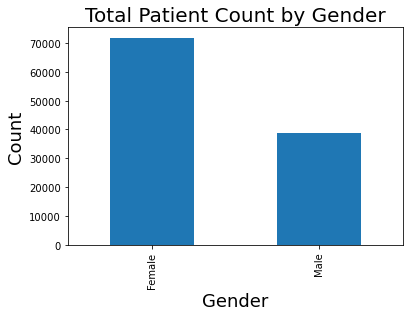

```python
df['gender'].value_counts().plot(kind='bar')
plt.xticks([0, 1], ['Female', 'Male'])
plt.xlabel('Gender', fontsize=18)
plt.ylabel('Count', fontsize=18)
plt.title('Total Patient Count by Gender', fontsize=20);
```

```python
# create mask for gender column
male = df['gender'] == 'M'
female = df['gender'] == 'F'
```

```python
#Segmenting attendance count by gender

df.gender[show].value_counts()
```

```
F    57245
M    30962
Name: gender, dtype: int64
```

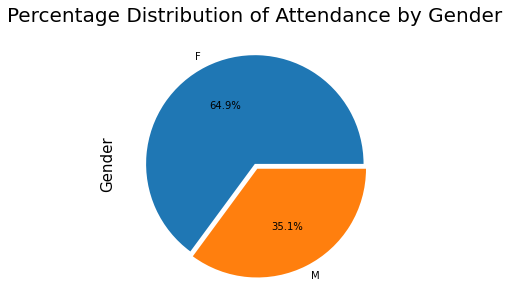

```python
# Visual chart of attendance by gender

df.gender[show].value_counts().plot(kind='pie', figsize=(5,5), autopct = '%.1f%%', explode=(0, 0.05))
plt.ylabel('Gender', fontsize=15)
plt.title('Percentage Distribution of Attendance by Gender', fontsize=20);
```

> Attendance distribution by gender shows 57,245 females showed up for scheduled appointment and this corresponds to 64.9% of total attendees as opposed to 30,962 males corresponding 35.1% of total attendees.

```python
#Segmenting missed appointments count by gender

df.gender[no_show].value_counts()
```

```
F    14594
M     7725
Name: gender, dtype: int64
```

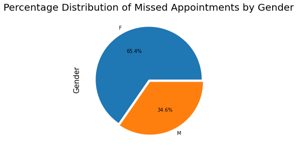

```python
# Visual chart of missed appointments by gender

df.gender[no_show].value_counts().plot(kind='pie', figsize=(5,5), autopct = '%.1f%%', explode=(0, 0.05) )
plt.ylabel('Gender', fontsize=15)
plt.title('Percentage Distribution of Missed Appointments by Gender', fontsize=20);
```

> Missed appointment distribution by gender shows 14,594 females missed scheduled appointment and this corresponds to 65.4% of total missed appointments as opposed to 7,725 males corresponding to 34.6% of missed appointments.

### Research Question 2 : Does age affect attendance?

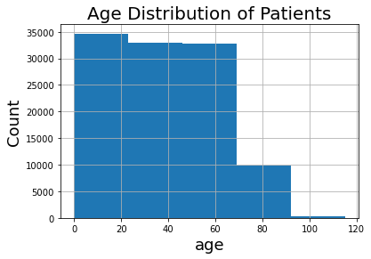

```python
# Histogram distribution of age
df['age'].hist(bins=5)
plt.xlabel('age', fontsize=18)
plt.ylabel('Count', fontsize=18)
plt.title('Age Distribution of Patients', fontsize=20)
```

> Age distribution is skewed to the right. The data shows that a large proportion of patients are between 1 to 70 years old.

```python
# Calculating the mean age of all patients
df['age'].mean()
```

```
37.089218826339504
```

```python
# Calculating median age
df['age'].median()
```

```
37.0
```

```python
# Mean age of attendance
df.age[show].mean()
```

```
37.790504154999034
```

```python
# Mean age of non-attendance
df.age[no_show].mean()
```

```
34.31766656212196
```

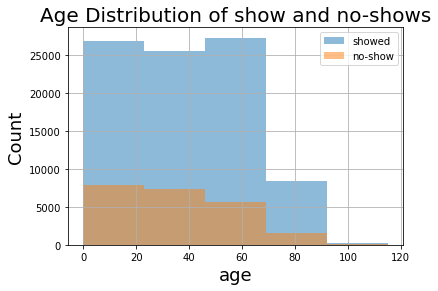

```python
# Age distribution of show and no-shows
df.age[show].hist(alpha = 0.5,bins=5, label = 'showed')
df.age[no_show].hist(alpha = 0.5,bins=5, label = 'no-show')
plt.xlabel('age', fontsize=18)
plt.ylabel('Count', fontsize=18)
plt.title('Age Distribution of show and no-shows', fontsize=20)
plt.legend();
```

```python
df.columns
```

```
Index(['patient_id', 'appointment_id', 'gender', 'scheduled_day',
       'appointment_day', 'age', 'neighbourhood', 'scholarship',
       'hypertension', 'diabetes', 'alcoholism', 'handicap', 'sms_received',
       'show', 'wait_days'],
      dtype='object')
```

### Research Question 3: Does sms notification and gender improve attendance?

```python
# Creating filter for patient's sms notification
notified = df.query('sms_received == 1')

# Creating filter for those not notified
no_sms = df.query('sms_received == 0')
```

```python
#Segmenting sms recipients who showed for appointment by gender
notified.query('show == 1')['gender'].value_counts()
```

```
F    17482
M     8216
Name: gender, dtype: int64
```

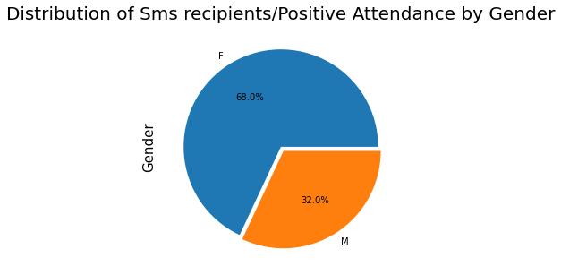

```python
# Pie chart of sms recipients who showed for appointments by gender
notified.query('show == 1')['gender'].value_counts().plot(kind='pie', figsize=(5,5), autopct ='%.1f%%', explode=(0, 0.05) )
plt.ylabel('Gender', fontsize=15)
plt.title('Distribution of Sms recipients/Positive Attendance by Gender', fontsize=20);
```

> 17,482 patients who recieved sms reminders and showed up for appointments as well are females corresponding to 68% as opposed to 8,216 males corresponding to 32%.

```python
#Segmenting sms recipients who missed their appointment by gender
notified.query('show == 0')['gender'].value_counts()
```

```
F    6720
M    3064
Name: gender, dtype: int64
```

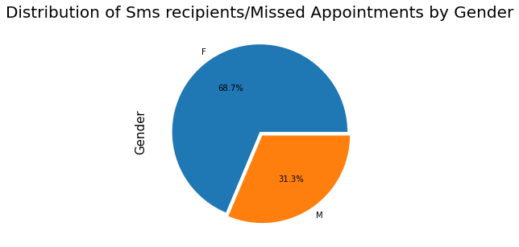

```python
# Pie chart of sms recipients who missed their appointment by gender

notified.query('show == 0')['gender'].value_counts().plot(kind='pie', figsize=(5,5), autopct ='%.1f%%', explode=(0, 0.05) )
plt.ylabel('Gender', fontsize=15)
plt.title('Distribution of Sms recipients/Missed Appointments by Gender', fontsize=20);
```

> 6,720 patients who recieved sms reminders but missed their appointments are females corresponding to 68.7% as opposed to 3,064 males corresponding to 31.3%.

```python
# Segmenting no-sms/show by gender
no_sms.query('show == 1')['gender'].value_counts()
```

```
F    39763
M    22746
Name: gender, dtype: int64
```

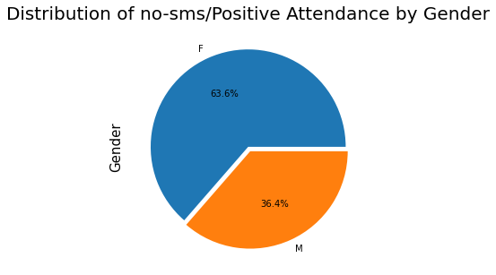

```python
# Pie chart of no-sms/show by gender
no_sms.query('show == 1')['gender'].value_counts().plot(kind='pie', figsize=(5,5), autopct ='%.1f%%', explode=(0, 0.05) )
plt.ylabel('Gender', fontsize=15)
plt.title('Distribution of no-sms/Positive Attendance by Gender', fontsize=20);
```

> 39,763 patients who did not recieve sms reminders but showed up for their appointments are females corresponding to 63.6% as opposed to 22,746 males corresponding to 36.4%.

```python
# Segmenting no-sms/no-show by gender
no_sms.query('show == 0')['gender'].value_counts()
```

```
F    7874
M    4661
Name: gender, dtype: int64
```

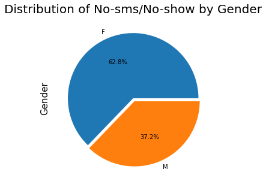

```python
# Pie chart of no-sms/no-show by gender
no_sms.query('show == 0')['gender'].value_counts().plot(kind='pie', figsize=(5,5), autopct ='%.1f%%', explode=(0, 0.05) )
plt.ylabel('Gender', fontsize=15)
plt.title('Distribution of No-sms/No-show by Gender', fontsize=20);
```

> 7,874 patients who did not recieve sms reminders and who also missed their appointments are females corresponding to 62.8% as opposed to 4,661 males corresponding to 37.2%.

```python
df.head()
```

|  | patient_id | appointment_id | gender | scheduled_day | appointment_day | age | neighbourhood | scholarship | hypertension | diabetes | alcoholism | handicap | sms_received | show | wait_days |
| --- | --- | --- | --- | --- | --- | --- | --- | --- | --- | --- | --- | --- | --- | --- | --- |
| 0 | 2.987250e+13 | 5642903 | F | 2016-04-29 18:38:08+00:00 | 2016-04-29 00:00:00+00:00 | 62 | JARDIM DA PENHA | 0 | 1 | 0 | 0 | 0 | 0 | 1 | -1 |
| 1 | 5.589978e+14 | 5642503 | M | 2016-04-29 16:08:27+00:00 | 2016-04-29 00:00:00+00:00 | 56 | JARDIM DA PENHA | 0 | 0 | 0 | 0 | 0 | 0 | 1 | -1 |
| 2 | 4.262962e+12 | 5642549 | F | 2016-04-29 16:19:04+00:00 | 2016-04-29 00:00:00+00:00 | 62 | MATA DA PRAIA | 0 | 0 | 0 | 0 | 0 | 0 | 1 | -1 |
| 3 | 8.679512e+11 | 5642828 | F | 2016-04-29 17:29:31+00:00 | 2016-04-29 00:00:00+00:00 | 8 | PONTAL DE CAMBURI | 0 | 0 | 0 | 0 | 0 | 0 | 1 | -1 |
| 4 | 8.841186e+12 | 5642494 | F | 2016-04-29 16:07:23+00:00 | 2016-04-29 00:00:00+00:00 | 56 | JARDIM DA PENHA | 0 | 1 | 1 | 0 | 0 | 0 | 1 | -1 |

### Research Question 4: How does Scholarship and Gender affect attendance?

```python
# Creating filter for scholarship
df_sch = df.query('scholarship == 1')
df_nosch = df.query('scholarship == 0')
```

```python
# Segmenting scholarship
df['scholarship'].value_counts()
```

```
0    99665
1    10861
Name: scholarship, dtype: int64
```

> 10,861 patients receive government sponsored welfare as opposed to 99,665 patients who do not receive scholarship.

```python
# Segmenting Patients who receive scholarship with positive attendance by gender
df_sch.query('show == 1')['gender'].value_counts()
```

```
F    6747
M    1536
Name: gender, dtype: int64
```

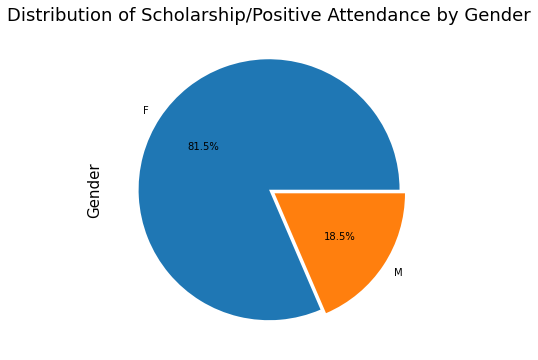

```python
# Pie chart of Patients who receive scholarship with positive attendance segmented by gender
df_sch.query('show == 1')['gender'].value_counts().plot(kind='pie', figsize=(6,6), autopct ='%.1f%%', explode=(0, 0.05))
plt.ylabel('Gender', fontsize=15)
plt.title('Distribution of Scholarship/Positive Attendance by Gender', fontsize=18);
```

```python
# Segmenting Patients who receive scholarship with missed appointment by gender

df_sch.query('show == 0')['gender'].value_counts()
```

```
F    2106
M     472
Name: gender, dtype: int64
```

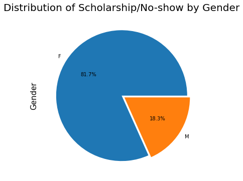

```python
# Pie chart Patients who receive scholarship with missed appointment by gender

df_sch.query('show == 0')['gender'].value_counts().plot(kind='pie', figsize=(6,6), autopct ='%.1f%%', explode=(0, 0.05))
plt.ylabel('Gender', fontsize=15)
plt.title('Distribution of Scholarship/No-show by Gender', fontsize=20);
```

> 2,106 patients who receive government sponsored welfare but missed their appointments are females corresponding to 81.7% while 472 are males corresponding to 18.3%.

```python
# Segmenting Patients who do not receive scholarship with positive attendance by gender

df_nosch.query('show == 1')['gender'].value_counts()
```

```
F    50498
M    29426
Name: gender, dtype: int64
```

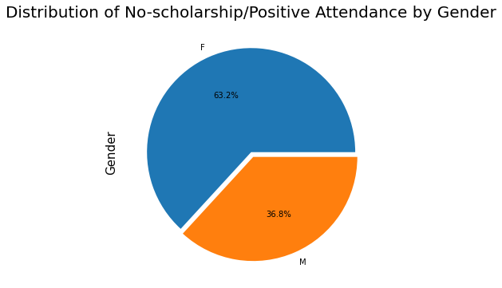

```python
# Pie chart Patients who do not receive scholarship with positive attendance by gender

df_nosch.query('show == 1')['gender'].value_counts().plot(kind='pie', figsize=(6,6), autopct ='%.1f%%', explode=(0, 0.05))
plt.ylabel('Gender', fontsize=15)
plt.title('Distribution of No-scholarship/Positive Attendance by Gender', fontsize=20);
```

50,498 patients who do not receive government sponsored welfare but showed up for their appointments are females corresponding to 63.2% while 29,426 are males corresponding to 36.8%.

```python
# Segmenting no-scholarship/no-show by gender
df_nosch.query('show == 0')['gender'].value_counts()
```

```
F    12488
M     7253
Name: gender, dtype: int64
```

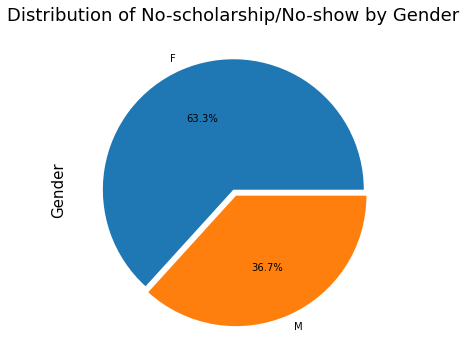

```python
# Pie chart of no-scholarship/ no-show by gender
df_nosch.query('show == 0')['gender'].value_counts().plot(kind='pie', figsize=(6,6), autopct ='%.1f%%', explode=(0, 0.05))
plt.ylabel('Gender', fontsize=15)
plt.title('Distribution of No-scholarship/No-show by Gender', fontsize=18);
```

> 12,488 patients who do not receive government sponsored welfare and missed their appointments are females corresponding to 63.3% while 7,253 are males corresponding to 36.7%.

```python
# Calculating correlation coefficient between columns.
#This will focus solely on the relationship between the dependent variable and the independent variables analysed in this discourse.

df.corr()
```

|  | patient_id | appointment_id | age | scholarship | hypertension | diabetes | alcoholism | handicap | sms_received | show | wait_days |
| --- | --- | --- | --- | --- | --- | --- | --- | --- | --- | --- | --- |
| patient_id | 1.000000 | 0.004023 | -0.004121 | -0.002877 | -0.006436 | 0.001608 | 0.011014 | -0.007915 | -0.009742 | 0.001456 | -0.001459 |
| appointment_id | 0.004023 | 1.000000 | -0.019106 | 0.022619 | 0.012759 | 0.022632 | 0.032946 | 0.014107 | -0.256613 | 0.162597 | -0.771830 |
| age | -0.004121 | -0.019106 | 1.000000 | -0.092463 | 0.504586 | 0.292391 | 0.095810 | 0.078032 | 0.012633 | 0.060327 | 0.034811 |
| scholarship | -0.002877 | 0.022619 | -0.092463 | 1.000000 | -0.019730 | -0.024894 | 0.035022 | -0.008587 | 0.001192 | -0.029134 | -0.030423 |
| hypertension | -0.006436 | 0.012759 | 0.504586 | -0.019730 | 1.000000 | 0.433085 | 0.087970 | 0.080083 | -0.006270 | 0.035704 | -0.017218 |
| diabetes | 0.001608 | 0.022632 | 0.292391 | -0.024894 | 0.433085 | 1.000000 | 0.018473 | 0.057530 | -0.014552 | 0.015181 | -0.027190 |
| alcoholism | 0.011014 | 0.032946 | 0.095810 | 0.035022 | 0.087970 | 0.018473 | 1.000000 | 0.004647 | -0.026149 | 0.000197 | -0.038520 |
| handicap | -0.007915 | 0.014107 | 0.078032 | -0.008587 | 0.080083 | 0.057530 | 0.004647 | 1.000000 | -0.024162 | 0.006077 | -0.019844 |
| sms_received | -0.009742 | -0.256613 | 0.012633 | 0.001192 | -0.006270 | -0.014552 | -0.026149 | -0.024162 | 1.000000 | -0.126428 | 0.398143 |
| show | 0.001456 | 0.162597 | 0.060327 | -0.029134 | 0.035704 | 0.015181 | 0.000197 | 0.006077 | -0.126428 | 1.000000 | -0.186228 |
| wait_days | -0.001459 | -0.771830 | 0.034811 | -0.030423 | -0.017218 | -0.027190 | -0.038520 | -0.019844 | 0.398143 | -0.186228 | 1.000000 |

### Conclusions

It is also important to note that correlation or the lack of it does not equate to causation or non-causation.

One important limitation of this analysis was that the scope was limited to just measures of central tendencies. In other words, we could not use authenticating statistical test to confirm the result.

Another potential area of further research would be to look at the impact of wait days/day of the week and how they potentially affect a patient's likelihood of making scheduled appointments.

```python
from subprocess import call
call(['python', '-m', 'nbconvert', 'Investigate_a_Dataset.ipynb'])
```

```
4294967295
```